# analysis

## Including Plots

```r
humans <- read_delim("pedestrian.csv",",")
```

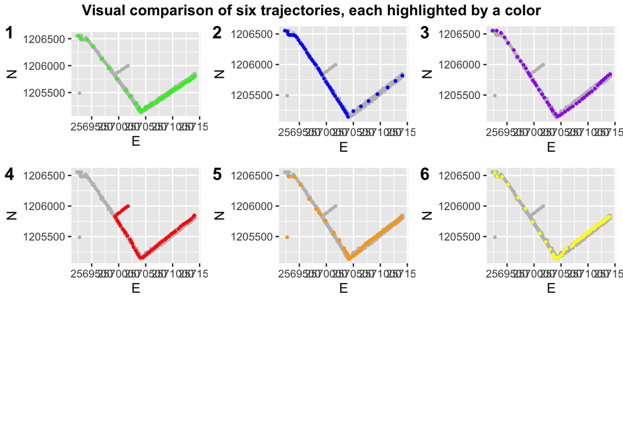

```r
humans <- st_as_sf(humans, coords = c("E", "N"), crs = 2056, remove = FALSE)

trajID1 <- humans %>%
  ggplot(aes(E, N))  +
  geom_point(aes(E,N), color="grey", size=0.75) +
  geom_point(data= humans %>% filter(TrajID == 1), color="green", size=0.75) +
  coord_fixed()

trajID2 <- humans %>%
  ggplot(aes(E, N))  +
  geom_point(aes(E,N), color="grey", size=0.75) +
  geom_point(data= humans %>% filter(TrajID == 2) , color="blue", size=0.75)

trajID3 <- humans %>%
  ggplot(aes(E, N))  +
  geom_point(aes(E,N), color="grey", size=0.75) +
  geom_point(data= humans %>% filter(TrajID == 3) , color="purple", size=0.75)

trajID4 <- humans %>%
  ggplot(aes(E, N))  +
  geom_point(aes(E,N), color="grey", size=0.75) +
  geom_point(data= humans %>% filter(TrajID == 4) , color="red", size=0.75)

trajID5 <- humans %>%
  ggplot(aes(E, N))  +
  geom_point(aes(E,N), color="grey", size=0.75) +
  geom_point(data= humans %>% filter(TrajID == 5) , color="orange", size=0.75)

trajID6 <- humans %>%
  ggplot(aes(E, N))  +
  geom_point(aes(E,N), color="grey", size=0.75) +
  geom_point(data= humans %>% filter(TrajID == 6) , color="yellow", size=0.75)

figure <- ggarrange(trajID1, trajID2, trajID3, trajID4, trajID5, trajID6,
                    labels = c("1", "2", "3", "4", "5", "6"),
                    ncol = 3, nrow = 3)
annotate_figure(figure, top = text_grob("Visual comparison of six trajectories, each highlighted by a color", color = "black", face = "bold", size = 12))
```

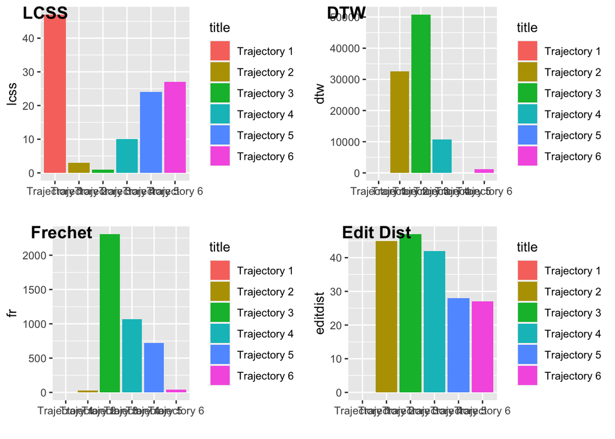

```r
traj1 <- humans %>% filter(TrajID == 1) %>% st_coordinates()
traj2 <- humans %>% filter(TrajID == 2) %>% st_coordinates()
traj3 <- humans %>% filter(TrajID == 3) %>% st_coordinates()
traj4 <- humans %>% filter(TrajID == 4) %>% st_coordinates()
traj5 <- humans %>% filter(TrajID == 5) %>% st_coordinates()
traj6 <- humans %>% filter(TrajID == 6) %>% st_coordinates()

similarity <- c("Traj", "LCSS")
lcss1 <- LCSS(traj1, traj1, 2, 20, 3)
lcss2 <- LCSS(traj1, traj2, 2, 20, 3)
lcss3 <- LCSS(traj1, traj3, 2, 20, 3)
lcss4 <- LCSS(traj1, traj4, 2, 20, 3)
lcss5 <- LCSS(traj1, traj5, 2, 20, 3)
lcss6 <- LCSS(traj1, traj6, 2, 20, 3)
lcss <- c(lcss1, lcss2, lcss3, lcss4, lcss5, lcss6)

dtw1 <- DTW(traj1, traj1, 3)
dtw2 <- DTW(traj1, traj2, 3)
dtw3 <- DTW(traj1, traj3, 3)
dtw4 <- DTW(traj1, traj4, 3)
dtw5 <- DTW(traj1, traj5, 3)
dtw6 <- DTW(traj1, traj6, 3)
dtw <- c(dtw1, dtw2, dtw3, dtw4, dtw5, dtw6)

fr1 <- Frechet(traj1, traj1)
fr2 <- Frechet(traj1, traj2)
fr3 <- Frechet(traj1, traj3)
fr4 <- Frechet(traj1, traj4)
fr5 <- Frechet(traj1, traj5)
fr6 <- Frechet(traj1, traj6)
fr <- c(fr1,fr2,fr3,fr4,fr5,fr6)

edit1 <- EditDist(traj1, traj1, 20)
edit2 <- EditDist(traj1, traj2, 20)
edit3 <- EditDist(traj1, traj3, 20)
edit4 <- EditDist(traj1, traj4, 20)
edit5 <- EditDist(traj1, traj5, 20)
edit6 <- EditDist(traj1, traj6, 20)
editdist <- c(edit1,edit2,edit3,edit4,edit5,edit6)


title <- c("Trajectory 1", "Trajectory 2", "Trajectory 3", "Trajectory 4", "Trajectory 5", "Trajectory 6")
similarity <- data.frame(title, lcss, dtw, fr, editdist)

plcss <- similarity %>%
    ggplot( aes(x=title, y=lcss, fill=title)) +
    geom_bar(stat="identity") +
    xlab("")

pdtw <- similarity %>%
    ggplot( aes(x=title, y=dtw, fill=title)) +
    geom_bar(stat="identity") +
    xlab("")
pfr <- similarity %>%
    ggplot( aes(x=title, y=fr, fill=title)) +
    geom_bar(stat="identity") +
    xlab("")
pedit <- similarity %>%
    ggplot( aes(x=title, y=editdist, fill=title)) +
    geom_bar(stat="identity") +
    xlab("")

figure <- ggarrange(plcss, pdtw, pfr, pedit,
                    labels = c("LCSS", "DTW", "Frechet", "Edit Dist"),
                    ncol = 2, nrow = 2)
figure
```

LCSS: The LCSS defines how many points of the second trajectory are matching to the points of the first 1 with taking into account a threshold. Trajectory 1 has a value of 47, which means all points match to trajectory 1. The higher the value the more similar the trajectories. Trajectory 3 has a low LCSS of around 2, which means trajectory 1 and 3 are not similar. Of the other trajectories number 6 has the highest similarity.

DTW: Dynamic time warping algorithm calculates the smallest warp path for the two trajectories. The lower the value the better. Of the other trajectories number 5 has the highest similarity and number 6 is as well very similar.

EditDist: returns the minimum number of edits required to allow the two trajectories to be considered equivalent. The smaller the number of edits, the more similar are the two trajectories. Trajectory 5 and 6 ned around 27 edits, which is the smallest amount and therefore the highest similarity to trajectory 1.

Summary: Trajectory 6 has the highest similarity when taking all 4 methods into account. Trajectory 5 is also quite similar in all of the methods. Trajectory 3 has the lowest similiarity in all of the methods. Trajectory 2 performes good at the frechet distance but bad in the other methods. Trajectory 4 performs always not worst but also never really good.